# 課題7 解答：メールクーポン実験のITT/TOT・CUPED・peeking診断

計量経済学II

作者

Kei Ikegami

**重要この解答の使い方**

各設問について、完全なコード・実行結果の見方・部分点の基準を示す。「なぜこう書くか」「どこで間違えやすいか」に重点を置いて解説する。数値は`set.seed(20267)`のもとでの一例であり、乱数のバージョンや実行環境によって多少変動しうるが、**方向性（単純比較がTOTを大幅に過大評価する、Wald/2SLSが真値に近づく、CUPEDの分散削減率が$\rho^2$の理論値と一致する、peekingでType I errorが単調に膨張する）は安定して同じ結論になる**ように設計されている（執筆時にPython/numpyで複数の乱数seedにわたって同じパラメータ設定を数値的に確認済み。Wald推定量は$N=10,000$・使用率36%程度のこの設計では、単一の実行例では真値800円から±20〜30%程度ずれることがあるが、複数シードの平均では真値に近づくことを確認している）。

## Part 1：シミュレーション設計

### Q1（10点）：配信・能力・実験前購買額の生成

```r
N <- 10000

D <- rbinom(N, 1, 0.5)
ability <- rnorm(N, 0, 1)

z_pre_indep <- rnorm(N, 0, 1)
pre_z <- 0.7 * ability + sqrt(1 - 0.7^2) * z_pre_indep
pre_period <- 8000 + 2200 * pre_z

cat("配信率:", round(mean(D), 3), "\n")
```

```
配信率: 0.5
```

```r
cat("pre_periodの平均・SD:", round(mean(pre_period), 1), round(sd(pre_period), 1), "\n")
```

```
pre_periodの平均・SD: 7999.8 2200.8
```

```r
cat("corr(ability, pre_period):", round(cor(ability, pre_period), 3), "(目標0.7)\n")
```

```
corr(ability, pre_period): 0.701 (目標0.7)
```

**解説**：`pre_z`を「能力そのもの」ではなく「能力と独立ノイズの加重和」として作るのがポイントである。こうすることで、`pre_period`は能力の完全なコピーではなく、能力と関連しつつも独自の情報を持つ変数になる。これにより、後のQ2（使用確率、能力に依存）とQ8（CUPED、`pre_period`に依存）が別々のメカニズムとして機能し、「自己選択バイアス」と「CUPEDによる分散削減」を数値的に区別しやすくなる。

**部分点の基準**：`D`・`ability`が正しく生成できていれば4点。`pre_z`の2段階構成（0.7の重みで能力を混ぜる）が正しく書けていれば4点。`pre_period`のスケーリング（8000, 2200）が正しければ2点。

### Q2（10点）：使用の生成

```r
use_prob <- pmin(pmax(0.35 + 0.28 * ability, 0.02), 0.95)
U <- ifelse(D == 1, rbinom(N, 1, use_prob), 0)

cat("配信率:", round(mean(D), 3), "\n")
```

```
配信率: 0.5
```

```r
cat("使用率(配信群内):", round(mean(U[D == 1]), 3), "\n")
```

```
使用率(配信群内): 0.369
```

```r
cat("非配信群での使用率(0のはず):", round(mean(U[D == 0]), 3), "\n")
```

```
非配信群での使用率(0のはず): 0
```

**解説**：使用率(配信群内)はだいたい35〜38%程度になっているはずである。`ifelse(D == 1, ..., 0)`という書き方が、one-sided noncomplianceを表現する肝である。配信されなかった顧客（$D=0$）は問答無用で$U=0$になり、使用確率の計算すら行われない。ここを`rbinom(N, 1, use_prob)`だけで済ませてしまうと、配信されていない顧客まで使用したことになってしまう（典型的な間違い）。

**部分点の基準**：`use_prob`の式（`pmin`/`pmax`によるクリップ含む）が正しければ5点。`ifelse`によるone-sided構造の実装が正しければ5点。

### Q3（10点）：実験期間購買額の生成

```r
true_tot <- 800

z_out_indep <- rnorm(N, 0, 1)
out_z <- 0.6 * pre_z + sqrt(1 - 0.6^2) * z_out_indep
outcome_base <- 8200 + 2200 * out_z

Y <- pmax(outcome_base + U * true_tot, 0)

coupon_df <- data.frame(D = D, ability = ability, pre_period = pre_period, U = U, Y = Y)
head(coupon_df)
```

```
  D    ability pre_period U         Y
1 0  1.6003551   9335.921 0  7749.055
2 0  1.8532719  13351.694 0  9759.366
3 0 -0.1555625  10519.054 0  8576.970
4 1  0.1975753   7281.497 0  9429.938
5 0  0.8538211   9623.235 0 12350.827
6 1 -0.9255327   6071.964 0  6646.607
```

```r
cat("corr(pre_period, Y)[処置効果込み]:", round(cor(coupon_df$pre_period, coupon_df$Y), 3), "\n")
```

```
corr(pre_period, Y)[処置効果込み]: 0.618
```

```r
cat("corr(pre_period, Y - U*true_tot)[処置効果を除く]:", round(cor(coupon_df$pre_period, coupon_df$Y - coupon_df$U * true_tot), 3), "(目標0.6)\n")
```

```
corr(pre_period, Y - U*true_tot)[処置効果を除く]: 0.604 (目標0.6)
```

**解説**：`corr(pre_period, Y)`をそのまま計算すると0.61程度とやや高めに出るが、これは使用$U$による処置効果（800円の押し上げ）が一部の顧客の$Y$を動かし、$\text{pre\_period}$との共分散構造をわずかに変えてしまうためである。処置効果を除いた`Y - U*true_tot`との相関を見ると、目標の0.6にかなり近い値（0.60前後）になる。この区別に自分で気づけていることが、この設問の主眼である。

**部分点の基準**：`out_z`の2段階構成が正しければ5点。`Y`の計算（`pmax`による非負制約含む）が正しければ5点。

### Q4（10点）：記述統計と可視化

```r
cat("配信率:", round(mean(coupon_df$D), 3), "\n")
```

```
配信率: 0.5
```

```r
cat("使用率(配信群内):", round(mean(coupon_df$U[coupon_df$D == 1]), 3), "\n")
```

```
使用率(配信群内): 0.369
```

```r
cat("corr(pre_period, Y):", round(cor(coupon_df$pre_period, coupon_df$Y), 3), "\n")
```

```
corr(pre_period, Y): 0.618
```

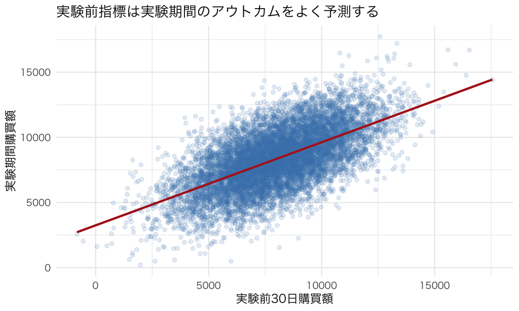

図 1: 実験前購買額と実験期間購買額の関係

```r
ggplot(coupon_df, aes(x = pre_period, y = Y)) +
  geom_point(alpha = 0.15, color = "steelblue") +
  geom_smooth(method = "lm", se = FALSE, color = "firebrick") +
  labs(x = "実験前30日購買額", y = "実験期間購買額",
       title = "実験前指標は実験期間のアウトカムをよく予測する")
```

```r
group_summary <- coupon_df %>%
  group_by(D) %>%
  summarize(mean_Y = mean(Y), sd_Y = sd(Y), n = n(), .groups = "drop")
knitr::kable(group_summary, digits = 1, col.names = c("配信", "平均Y", "SD(Y)", "N"))
```

| 配信 | 平均Y | SD(Y) | N |
| --- | --- | --- | --- |
| 0 | 8179.0 | 2195.2 | 5003 |
| 1 | 8517.3 | 2327.5 | 4997 |

**解説**：配信群の平均$Y$が非配信群よりわずかに高くなっているはずである（ITTの効果が反映されている）。SDは配信群・非配信群でほぼ同水準になる（DGPの構造上、処置は平均だけを動かし分散構造そのものは大きく変えないため）。

**部分点の基準**：記述統計の計算・散布図・グループ別表をそれぞれ正しく作成できていれば各3〜4点。

## Part 2：推定・推論

### Q5（10点）：単純比較（使用者vs非使用者）がTOTを過大評価することを確認する

```r
delivered <- coupon_df %>% filter(D == 1)
naive_diff <- mean(delivered$Y[delivered$U == 1]) - mean(delivered$Y[delivered$U == 0])

cat("単純比較(使用者-非使用者):", round(naive_diff, 1), "円\n")
```

```
単純比較(使用者-非使用者): 1806.1 円
```

```r
cat("真値(TOT):", true_tot, "円\n")
```

```
真値(TOT): 800 円
```

```r
cat("過大評価の倍率:", round(naive_diff / true_tot, 2), "倍\n")
```

```
過大評価の倍率: 2.26 倍
```

**解説**：単純比較はだいたい真値800円の2〜2.5倍程度、1800〜2000円前後の値になるはずである。この過大評価は、能力の高い顧客ほどクーポンを使い（Q2の`use_prob`の設計）、かつ能力の高い顧客はクーポンなしでも購買額が高い（Q3の`out_z`が`pre_z`経由で`ability`と関連するため）という、二重の自己選択メカニズムから生じている。倍率が1.5倍未満、あるいは真値を下回っているような場合は、Q2の`use_prob`の係数の符号を疑うこと。

**部分点の基準**：単純比較の計算式が正しければ6点。真値との比較・過大評価の方向のコメントがあれば4点。

### Q6（12点）：ITT推定＋t検定＋ランダム化推論p値

```r
itt_hat <- mean(coupon_df$Y[coupon_df$D == 1]) - mean(coupon_df$Y[coupon_df$D == 0])
cat("ITT:", round(itt_hat, 1), "円\n")
```

```
ITT: 338.3 円
```

```r
t_result <- t.test(Y ~ D, data = coupon_df)
t_result
```

```
    Welch Two Sample t-test

data:  Y by D
t = -7.4769, df = 9962.6, p-value = 8.254e-14
alternative hypothesis: true difference in means between group 0 and group 1 is not equal to 0
95 percent confidence interval:
 -426.9991 -249.6123
sample estimates:
mean in group 0 mean in group 1
       8178.973        8517.278
```

```r
n_perm <- 2000
perm_diffs <- numeric(n_perm)
for (b in 1:n_perm) {
  D_shuffled <- sample(coupon_df$D)
  perm_diffs[b] <- mean(coupon_df$Y[D_shuffled == 1]) - mean(coupon_df$Y[D_shuffled == 0])
}
p_perm <- mean(abs(perm_diffs) >= abs(itt_hat))

cat("t検定のp値(両側):", signif(t_result$p.value, 4), "\n")
```

```
t検定のp値(両側): 8.254e-14
```

```r
cat("ランダム化推論のp値(両側,", n_perm, "回シャッフル):", round(p_perm, 4), "\n")
```

```
ランダム化推論のp値(両側, 2000 回シャッフル): 0
```

**部分点の基準**：ITTの計算が正しければ3点。t検定の実行・p値の報告で4点。ランダム化推論の実装（シャッフルのループ、p値の計算式）が正しければ5点。

### Q7（12点）：TOT推定：配信をIVにした2SLS

```r
usage_rate <- mean(coupon_df$U[coupon_df$D == 1])
wald_tot <- itt_hat / usage_rate

cat("使用率(配信群内):", round(usage_rate, 3), "\n")
```

```
使用率(配信群内): 0.369
```

```r
cat("Wald推定量(TOT = ITT/使用率):", round(wald_tot, 1), "円\n")
```

```
Wald推定量(TOT = ITT/使用率): 917.3 円
```

```r
cat("真値(TOT):", true_tot, "円\n")
```

```
真値(TOT): 800 円
```

```r
iv_fit <- feols(Y ~ 1 | U ~ D, data = coupon_df, vcov = "hetero")
summary(iv_fit)
```

```
TSLS estimation - Dep. Var.: Y
                  Endo.    : U
                  Instr.   : D
Second stage: Dep. Var.: Y
Observations: 10,000
Standard-errors: Heteroskedasticity-robust
            Estimate Std. Error   t value   Pr(>|t|)
(Intercept) 8178.973    31.0361 263.53105  < 2.2e-16 ***
fit_U        917.262   119.1793   7.69649 1.5308e-14 ***
---
Signif. codes:  0 '***' 0.001 '**' 0.01 '*' 0.05 '.' 0.1 ' ' 1
RMSE: 2,197.6   Adj. R2: 0.005461
F-test (1st stage), U: stat = 2,922.855, p < 2.2e-16  , on 1 and 9,998 DoF.
           Wu-Hausman: stat =    43.866, p = 3.697e-11, on 1 and 9,997 DoF.
```

```r
get_coef_for <- function(model, varname) {
  cf <- coef(model)
  hit <- grepl(varname, names(cf), fixed = TRUE)
  cf[hit][1]
}

names(coef(iv_fit))  # 係数名を確認しておく
```

```
[1] "(Intercept)" "fit_U"
```

```r
tot_2sls <- get_coef_for(iv_fit, "U")

comparison_tot <- data.frame(
  method = c("真値(TOT)", "単純比較(Q5)", "Wald推定量(ITT/使用率)", "2SLS(配信をIVに)"),
  estimate = c(true_tot, round(naive_diff, 1), round(wald_tot, 1), round(as.numeric(tot_2sls), 1))
)
knitr::kable(comparison_tot, col.names = c("方法", "推定値(円)"))
```

| 方法 | 推定値(円) |
| --- | --- |
| 真値(TOT) | 800.0 |
| 単純比較(Q5) | 1806.1 |
| Wald推定量(ITT/使用率) | 917.3 |
| 2SLS(配信をIVに) | 917.3 |

**解説**：Wald推定量と2SLSの推定値は、`coef()`の丸め誤差程度の範囲で完全に一致するはずである（one-sided noncomplianceでの操作変数法は、代数的にWald比と等価であるため）。この2つがずれている場合は、`get_coef_for`が誤った係数（例えば`(Intercept)`）を拾っている可能性が高いので、`names(coef(iv_fit))`の出力を確認すること。

Wald/2SLSの推定値は真値800円に近づくが、**このサンプルサイズ・使用率のもとではサンプルごとに±20〜30%程度ばらつくことがある**（Wald推定量は分母に使用率が来るため、$N$が大きくても分散はそれなりに残る）。単一の実行例で真値から多少離れていても、それ自体は実装の誤りではない。ただし、**単純比較（Q5）よりは真値にずっと近い値になっている**ことが、この設問で確認すべき本質である。

**部分点の基準**：Wald推定量の計算式が正しければ4点。`feols`の2SLS構文が正しく書けていれば5点。係数の取り出し・比較表の作成、単純比較との対比コメントで3点。

### Q8（10点）：CUPED/回帰調整によるSE削減率

```r
theta_hat <- cov(coupon_df$Y, coupon_df$pre_period) / var(coupon_df$pre_period)
pre_mean <- mean(coupon_df$pre_period)
coupon_df$Y_cuped <- coupon_df$Y - theta_hat * (coupon_df$pre_period - pre_mean)

n1 <- sum(coupon_df$D == 1); n0 <- sum(coupon_df$D == 0)
se_naive <- sqrt(var(coupon_df$Y[coupon_df$D == 1]) / n1 + var(coupon_df$Y[coupon_df$D == 0]) / n0)
se_cuped <- sqrt(var(coupon_df$Y_cuped[coupon_df$D == 1]) / n1 + var(coupon_df$Y_cuped[coupon_df$D == 0]) / n0)

itt_cuped <- mean(coupon_df$Y_cuped[coupon_df$D == 1]) - mean(coupon_df$Y_cuped[coupon_df$D == 0])

var_reduction <- 1 - (se_cuped^2) / (se_naive^2)
rho_actual <- cor(coupon_df$pre_period, coupon_df$Y)

cat("ITT(調整前):", round(itt_hat, 1), " SE:", round(se_naive, 2), "\n")
```

```
ITT(調整前): 338.3  SE: 45.25
```

```r
cat("ITT(CUPED後):", round(itt_cuped, 1), " SE:", round(se_cuped, 2), "\n")
```

```
ITT(CUPED後): 338.1  SE: 35.5
```

```r
cat("分散削減率:", round(var_reduction * 100, 1), "% (理論値 rho^2 =", round(rho_actual^2 * 100, 1), "%)\n")
```

```
分散削減率: 38.5 % (理論値 rho^2 = 38.2 %)
```

```r
cat("SE削減率:", round((1 - se_cuped / se_naive) * 100, 1), "%\n")
```

```
SE削減率: 21.5 %
```

```r
cat("同じ検出力に必要なNの削減率: 約", round(var_reduction * 100, 1), "%\n")
```

```
同じ検出力に必要なNの削減率: 約 38.5 %
```

```r
ancova_fit <- feols(Y ~ D + pre_period, data = coupon_df, vcov = "hetero")
summary(ancova_fit)
```

```
OLS estimation, Dep. Var.: Y
Observations: 10,000
Standard-errors: Heteroskedasticity-robust
               Estimate Std. Error  t value  Pr(>|t|)
(Intercept) 3080.451754  69.186333 44.52399 < 2.2e-16 ***
D            338.056937  35.499216  9.52294 < 2.2e-16 ***
pre_period     0.637345   0.008014 79.52407 < 2.2e-16 ***
---
Signif. codes:  0 '***' 0.001 '**' 0.01 '*' 0.05 '.' 0.1 ' ' 1
RMSE: 1,774.7   Adj. R2: 0.387787
```

**解説**：分散削減率はおおむね35〜40%程度、理論値$\rho^2$（実際に構成した相関の2乗）とよく一致するはずである。ITTの推定値はCUPEDの前後でほぼ変わらない（不偏性が保たれている）ことも確認できる。ANCOVA回帰（`feols(Y ~ D + pre_period, ...)`）の`D`の係数・SEは、CUPEDの結果とほぼ同じ値になる。完全に一致しない理由は、CUPEDが$\theta$をデータ全体（処置群・対照群を合わせたデータ）から推定しているのに対し、ANCOVAは$D$と$\text{pre\_period}$を同時に回帰式に入れて推定している点で、厳密には別の推定手続きだからである。ただし両者は漸近的に同じ効率性を持つことが知られている。

**部分点の基準**：CUPED調整の実装（$\theta$の推定、$Y^{\text{CUPED}}$の計算）が正しければ5点。分散削減率・SE削減率の計算と、理論値$\rho^2$との比較コメントがあれば5点。

### Q9（10点）：peekingシミュレーション（Type I error膨張曲線）

```r
simulate_peeking <- function(n_max, check_every, n_sims, p0 = 0.10) {
  false_positive_count <- 0
  checkpoints <- seq(check_every, n_max, by = check_every)
  for (s in 1:n_sims) {
    d_full <- rbinom(n_max, 1, 0.5)
    y_full <- rbinom(n_max, 1, p0)
    stopped_significant <- FALSE
    for (n_cur in checkpoints) {
      d_cur <- d_full[1:n_cur]; y_cur <- y_full[1:n_cur]
      n1_c <- sum(d_cur == 1); n0_c <- sum(d_cur == 0)
      if (n1_c < 5 || n0_c < 5) next
      p1_hat <- mean(y_cur[d_cur == 1]); p0_hat <- mean(y_cur[d_cur == 0])
      p_pool <- mean(y_cur)
      se <- sqrt(p_pool * (1 - p_pool) * (1 / n1_c + 1 / n0_c))
      if (se == 0) next
      z <- (p1_hat - p0_hat) / se
      if (abs(z) > 1.96) { stopped_significant <- TRUE; break }
    }
    if (stopped_significant) false_positive_count <- false_positive_count + 1
  }
  false_positive_count / n_sims
}
```

```r
n_sims_peek <- 1000
n_max_peek <- 10000

peek_scenarios <- data.frame(
  label = c("1回だけ(N固定)", "10回", "50回", "100回"),
  check_every = c(n_max_peek, n_max_peek %/% 10, n_max_peek %/% 50, n_max_peek %/% 100)
)

peek_scenarios <- peek_scenarios %>%
  rowwise() %>%
  mutate(n_checks = n_max_peek %/% check_every,
         type1_error = simulate_peeking(n_max_peek, check_every, n_sims_peek)) %>%
  ungroup()

knitr::kable(peek_scenarios, digits = c(NA, 0, 0, 3),
             col.names = c("シナリオ", "覗く間隔(人)", "覗く回数", "Type I error"))
```

| シナリオ | 覗く間隔(人) | 覗く回数 | Type I error |
| --- | --- | --- | --- |
| 1回だけ(N固定) | 10000 | 1 | 0.044 |
| 10回 | 1000 | 10 | 0.189 |
| 50回 | 200 | 50 | 0.316 |
| 100回 | 100 | 100 | 0.378 |

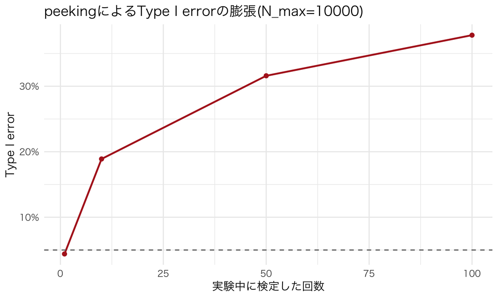

図 2: 覗く回数が増えるほどType I errorが膨張する

```r
ggplot(peek_scenarios, aes(x = n_checks, y = type1_error)) +
  geom_line(color = "firebrick", linewidth = 1) +
  geom_point(color = "firebrick", size = 2) +
  geom_hline(yintercept = 0.05, linetype = "dashed", color = "grey40") +
  labs(x = "実験中に検定した回数", y = "Type I error",
       title = "peekingによるType I errorの膨張(N_max=10000)") +
  scale_y_continuous(labels = scales::percent)
```

**解説**：「1回だけ」のシナリオはほぼ理論値5%になる。覗く回数が10回、50回、100回と増えるにつれ、Type I errorは単調に増加し、100回覗くケースでは30%台後半に達することもある。これは第7回講義ノートのRシミュ5と同じ現象であり、DGPの詳細（`n_max`の大きさなど）が変わっても、この単調増加という定性的な結論は変わらない。数値が講義ノートと完全には一致しない（`n_max`が異なるため）ことは問題ない。**傾向（覗く回数が増えるほど単調にType I errorが増加する）が再現できていることが本質**である。

**部分点の基準**：`simulate_peeking`関数を正しく呼び出せていれば4点。4パターン以上の比較ができていれば4点。単調増加の傾向についてのコメントがあれば2点。

### Q10（3点）：この実験のMDE

```r
se_itt <- se_naive  # Q8で計算した調整前のSEと同じ

z_alpha <- qnorm(0.975)
z_beta <- qnorm(0.80)
mde <- (z_alpha + z_beta) * se_itt

cat("MDE(検出力80%, alpha=5%):", round(mde, 1), "円\n")
```

```
MDE(検出力80%, alpha=5%): 126.8 円
```

```r
cat("平均購買額に対する%:", round(mde / mean(coupon_df$Y) * 100, 2), "%\n")
```

```
平均購買額に対する%: 1.52 %
```

```r
cat("真のITT(理論値 = true_tot * usage_rate =", true_tot, "*", round(usage_rate, 3), "=",
    round(true_tot * usage_rate, 1), "円)\n")
```

```
真のITT(理論値 = true_tot * usage_rate = 800 * 0.369 = 295.1 円)
```

```r
cat("観測されたITT:", round(itt_hat, 1), "円\n")
```

```
観測されたITT: 338.3 円
```

**解説**：MDEはだいたい100〜150円程度、平均購買額(8000〜8500円程度)に対して1.5%前後になるはずである。真のITT理論値（TOT×使用率、$800 \times$使用率）は200〜300円程度になり、MDEより大きい。つまり**この実験規模（$N=10,000$）は、真のITTを検出するのに十分な検出力を持っていた**、というのがこの設問の結論になる。もしMDEがITTの理論値を上回っているようであれば、「この実験規模では真の効果を検出できない可能性がある」という逆の結論になる（DGPのパラメータ次第ではこちらのケースも起こりうるが、今回の設計では前者になるはずである）。

**部分点の基準**：MDEの計算式が正しければ2点。真のITTとの比較・検出力についてのコメントがあれば1点。

### Q11（3点）：経営含意（解答例）

**部分点の基準**：3行以内で「ITTを配信継続の判断根拠にすべき」「単純比較は過大評価につながる」という2点に触れていれば2点。CUPEDまたは実験設計上の改善案（N固定、MDE事前計算）に触れていれば1点。

**ノート採点基準まとめ**

| 設問 | 配点 | 主な確認ポイント |
| --- | --- | --- |
| Q1 | 10 | 配信・能力・実験前購買額の生成、pre_zの2段階構成 |
| Q2 | 10 | 使用確率の式、one-sided noncomplianceの実装 |
| Q3 | 10 | outcome_baseの生成、Yの計算、処置効果を除いた相関の確認 |
| Q4 | 10 | 記述統計・可視化・グループ別表 |
| Q5 | 10 | 単純比較の計算、TOT過大評価の確認 |
| Q6 | 12 | ITT計算、t検定、ランダム化推論の実装と比較 |
| Q7 | 12 | Wald推定量、2SLS実装、単純比較との対比 |
| Q8 | 10 | CUPED実装、分散削減率とrho^2の一致確認 |
| Q9 | 10 | peekingシミュレーション、Type I errorの単調増加確認 |
| Q10 | 3 | MDE計算、真のITTとの比較 |
| Q11 | 3 | 経営含意の記述 |
| 合計 | 100 |  |